# Twitch Graph

2024-07-24

## Twitch Gamers

**Twitch.tv** è una piattaforma di livestreaming di proprietà di Amazon lanciata il 6 giugno 2011. La piattaforma consente principalmente lo streaming di videogiochi, trasmissioni di eventi e competizioni eSports (Competizioni Videoludiche). Poiché gli utenti possono seguirsi a vicenda, esiste una rete sociale sottostante a cui si può accedere tramite l’API pubblica.  
Il dataset Twitch Graph e il risultato del crawling della più grande componente connessa di questa rete sociale a partire dall’utente chiamato *“Lowko”*, eseguito nell’aprile del 2018 da [Benedek Rozemberczki e Rik Sarkar (2021)](https://arxiv.org/pdf/2101.03091.pdf). Il dataset Twitch Gamers rilasciato è un sottoinsieme pulito della rete sociale originale, alla quale è stato eseguito un filtraggio sui nodi e sugli archi in base ai seguenti principi:

- Non dovevano esserci attributi mancanti.
- Doveva esserci una relazione reciproca tra le varie coppie.
- I nodi dovevano far parte della componente connessa più grande.

Il risultato di questo processo di pulizia dei dati è una rete sociale indiretta, con una sola componente connessa con circa 168 mila nodi e 6,79 milioni di archi.

## Obiettivo

L’obiettivo di questa analisi è esplorare e comprendere la struttura della rete sociale utilizzando diversi metodi di analisi delle reti: *Local analysis*, *Group analysis* e *Global analysis*.

## Domande

1. Quali sono gli account con il maggior numero di relazioni.
2. Quali sono gli account con il maggior numero di visualizzazioni.
3. Quali sono gli account “centrali” della rete sociale utilizzando le misure di centralità semplice.
4. Qual è il miglior algoritmo di raggruppamento. Come viene suddivisa la rete.
5. La rete ridotta è ancora connessa. La distribuzione dei gradi della rete è una Power-law.

## Introduzione

Il dataset Twitch Gamers è suddiviso in due dataset, uno contenete i nodi della rete sociale e l’altro contenente le relazioni reciproche tra i vari account.

Il dataset dei nodi è composto da 9 variabili:

- **id** (int): L’identificativo dell’account.
- **created_at** (date): La data di creazione dell’account.
- **last_stream** (date): La data dell’ultima stream eseguita.
- **account_life_time** (int): Numero di giorni tra la data di creazione dell’account e l’ultima stream.
- **views** (int): Conteggio delle visualizzazione ricevute.
- **language** (char): Lingua nella quale vengono fatte le streaming.
- **explicit_content** (char): Indica se il contenuto trasmesso è esplicito o no.
- **dead_account** (char): Indica se l’account è “morto” o no.
- **affiliate** (char): Indica se l’account ha ottenuto la partner con Twitch o no.

Mentre il dataset degli archi contiene sono due variabili: **id_1** e **id_2** che indicano la relazione reciproca tra gli identificativi dei due account.

## 1. Top 10 account per numero di relazioni

Il seguente grafico presenta i primi 10 account nel dataset in base al maggior numero di relazione della rete sociale, ordinati in base al numero di relazioni degli stessi.

- Osservando il grafico si emerge una correlazione tra il decremento delle relazioni associate a un determinato account e la conseguente riduzione delle visualizzazioni ricevute. Il valore di correlazione calcolato tramite Pearson è 0.726.
- L’unica eccezione marcata è rappresentata dall’account **155127**, anche occupando l’ottava posizione nella graduatoria, si discosta dagli altri con un numero di visualizzazioni significativo, circa 80 milioni dalla nona e dedima posizione.
- Un’altra correlazione interessante e quella tra il numero di relazioni instaurate e la longevità dell’account sulla piattaforma. Il valore di correlazione calcolato tramite Pearson è 0.304.

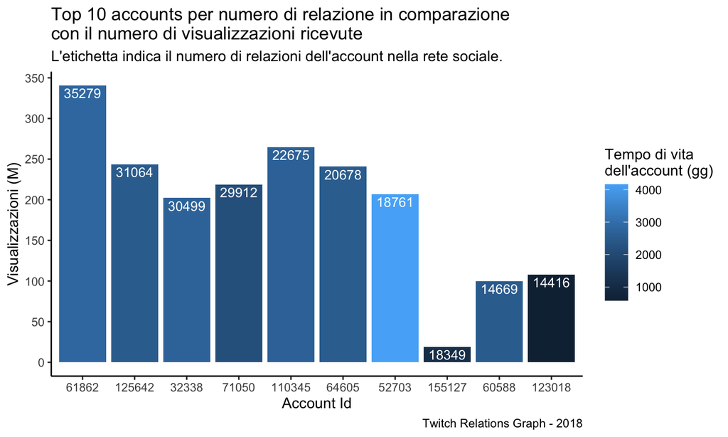

## 2. Top 10 account per numero di visualizzazioni

Il seguente grafico presenta i primi 10 account nel dataset in base al maggior numero di visualizzazioni ricevute, ordinati in base al numero di relazioni degli stessi.

- In questo caso, invece, la correlazione tra numero di relazioni e visualizzazione è piu debole e negativa, infatti il valore di correlazione calcolato tramite Pearson è -0.438.
- La correlazione tra il numero di relazioni e la longevità dell’account sulla piattaforma, rimane più o meno della stessa intensità, con un valore di correlazione calcolato tramite Pearson è 0.357.

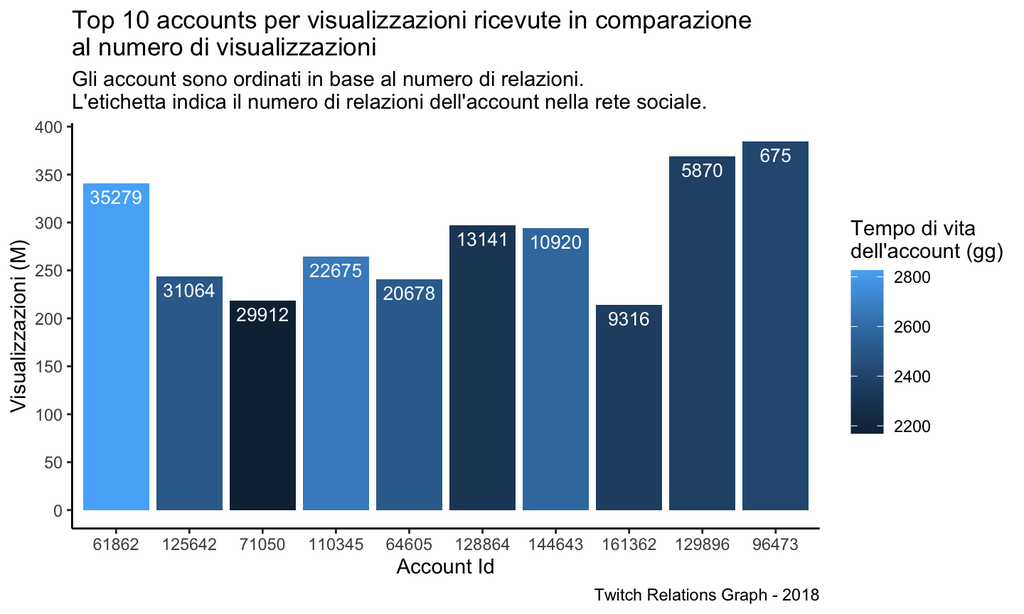

## Camparazione tra gli account delle due Top 10

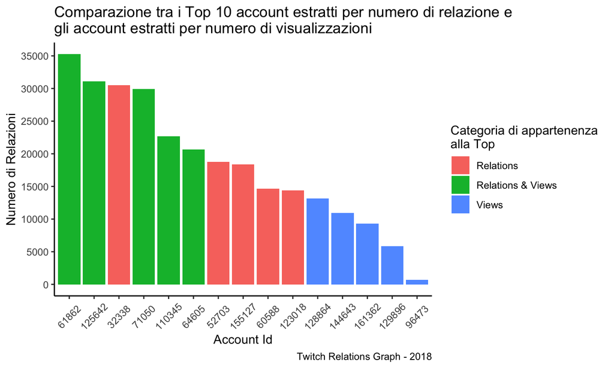

Mettendo in relazione gli account della rete sociale ottenuti con i due metodi precedenti e mettendoli a confronto, si può notare:

- Gli account nelle posizione più alte della graduatoria sono stati selezionati da entrambi i metodi, ovvero dal numero di relazioni e dalle visualizzazioni ricevute. Unica eccezione data dalla terza posizione dove l’account è stato selezionato solo dal primo metodo.
- Gli account a metà classifica sono quelli selezionati in base al numero di relazioni massime all’interno della rete sociale.
- Gli account in fondo alla classifica sono quelli selezionati in base al numero visualizzazioni ricevute.

## Riduzione della numerosità della rete sociale

- In base ai risultati ottenuti dalle due analisi esplorative precedenti, e avendo visto che non era possibile effettuare le analisi successive utilizzando l’intera rete sociale del dataset, ho deciso di ridurre la numerosità della rete a 25.000 nodi. La riduzione è stata fatta dopo aver ordinato i nodi della rete in modo decrescente per numero di relazioni, numero di visualizzazioni e longevità dell’account. Selezionando quindi i primi 25.000 nodi. della rete dopo l’ordinamento, il numero di archi della rete è stato ridotto, di conseguenza, a 2.681.212.

## 3. Confronto tra le misure di centralità semplice

- Degree Centrality
- Closeness Centrality
- Betweenness Centrality

## 3.1 Degree Centrality

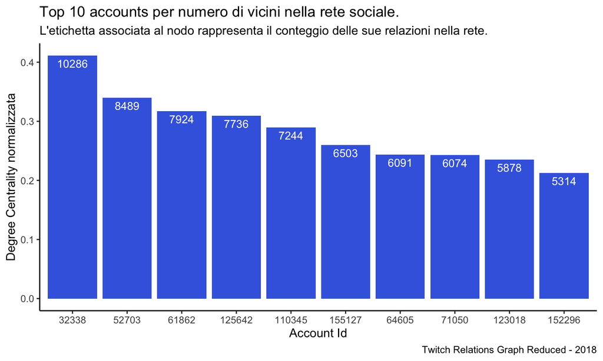

La misura di centralità *degree centrality* è stata calcolata in modo normalizzato, utilizzando la formula \(Dc_N(v) = \frac{d(v)}{n-1}\), in modo tale da rendere possibile il confronto tra i vari nodi.  
Dal grafico possiamo osservare che i primi 10 nodi della rete sociale presentano una connessione con gli altri nodi della rete che varia da un massimo di circa il 41% a un minimo di circa il 21%.  
La limitazione di questa misura di centralità è che considera solo il numero di relazioni per determinare l’importanza di un nodo nella rete. Questa limitazione può essere superata calcolando anche la *closeness centrality* e la *betweenness centrality*.

## 3.2 Closeness Centrality

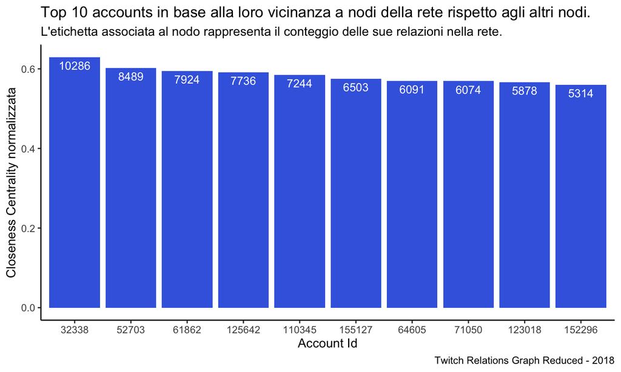

Anche per la *closeness centrality* è stato calcolato il valore normalizzato in modo tale da permettere il confronto tra i vari nodi, utilizzando la formula \(Cc_N(v) = \frac{n-1}{\sum_{u \in V} dist(v, u)}\).  
Il valore della closeness centrality normalizzata per i primi 10 nodi è notevolmente omogeneo, variando da un massimo di circa 0.63 a un minimo di circa 0.56. Questo suggerisce che questi nodi sono centrali nella rete, facilitando un accesso efficiente agli altri nodi, ad esempio per la diffusione di informazioni e notizie.

## 3.3 Betweenness Centrality

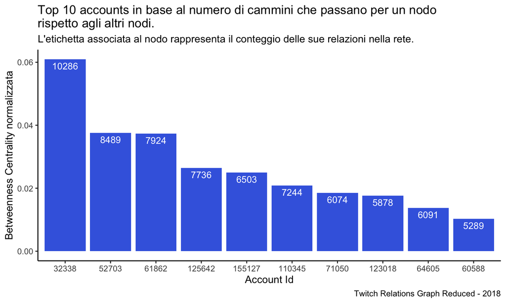

Anche il valore della *betweenness centrality* è stato normalizzato per consentire un confronto tra i nodi della rete, utilizzando la formula \(Bc_N(v) = \frac{2B}{(n-1)(n-2)}\).  
Possiamo notare come il valore di betweenness centrality massimo riscontrato, pari a circa 0.061, è molto basso rispetto al massimo possibile, ovvero 1, ma questo comunque non vuol dire che il nodo in questione non sia *“centrale”* nella rete. Infatti, la betweenness centrality calcola quanto un nodo svolga un ruolo di ponte o intermediario tra altri nodi nella rete. In questa rete, essendo una *giant component*, non è necessario che i nodi svolgano questo tipo di compito.

## Comparazione tra i nodi estratti dalle misure di centralità semplice

Il grafico seguente mostra i nodi selezionati dalle tre misure di centralità. Possiamo notare che tutti i nodi mostrano un aumento nei valori delle tre misure di centralità all’aumentare della posizione nella graduatoria. Inoltre, su un totale di 11 nodi selezionati, i primi 9 sono stati identificati da tutte e tre le misure di centralità. Il decimo nodo è stato selezionato solo dalla degree centrality e closeness centrality, mentre l’undicesimo solo dalla betweenness centrality, coerentemente con le considerazioni precedenti.

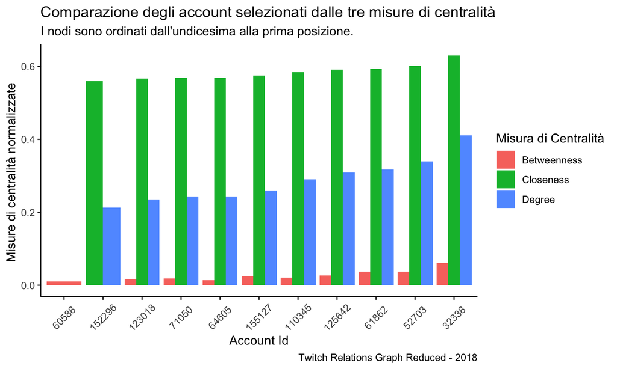

## 4. Algoritmi di grouping

Nel contesto degli algoritmi di raggruppamento dei nodi nella rete, ho calcolato il valore di **modularity** per ciascuno di essi. La modularity misura l’efficacia della suddivisione della rete proposta da ciascun algoritmo di individuazione delle comunità, ovvero quanto efficacemente l’algoritmo separa i diversi tipi di nodi all’interno della rete. Possiamo notare che l’algoritmo *louvain* ha il valore di modularity più alto rispetto agli altri, che invece, apparte per l’algoritmo *label_prop*, hanno più o meno lo stesso valore. Per quanto riguarda gli ultimi tre algoritmi che presentano il valore di modularity pari a **0**, ciò è attribuito a due motivi principali:

- Per quanto riguarda l’algoritmo *optimal*, la sua computazione ha generato un errore che ha impedito la corretta valutazione.
- Invece, per gli algoritmi *edge_betweenness* e *spinglass*, nonostante la rete sociale ridotta, richiedevano una computatione troppo onerosa in termini di tempo.

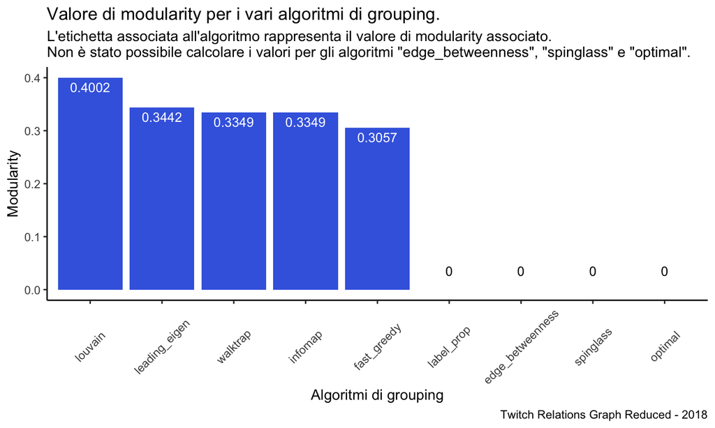

Per l’analisi delle comunità presenti nella rete, sono stati utilizzati i primi due algoritmi identificati dal valore di modularity, visto nel grafico precedente, *louvain* e *cluster_leading_eigen*.  
L’algoritmo *louvain* ha identificato 11 comunità, con un numero di nodi rispettivamente:  
7327, 5118, 1240, 5151, 752, 562, 3441, 347, 124, 381, 557

Invece, l’algoritmo *cluster_leading_eigen* ha identificato 3 comunità, con un numero di nodi rispettivamente:  
11835, 7151, 6014

Nell’analisi delle comunità identificate dai due algoritmi, non è emersa una distinzione significativa nei valori degli attributi dei nodi all’interno dei diversi raggruppamenti. Questo suggerisce che le suddivisioni della rete in comunità, possono non rispecchiarsi sulle caratteristiche individuali dei nodi, ma si basano quasi unicamente sulla struttura della rete stessa.

## 5. Global Analisys della rete

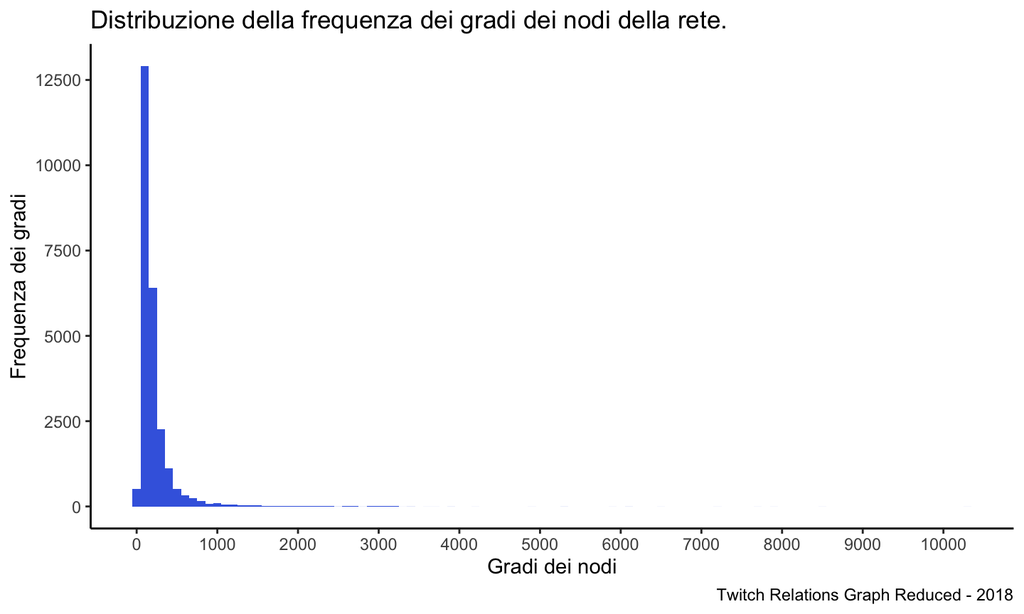

- Un altro metodo per verificare se una rete è di tipo Scale-free è quello di graficare il valore di *CCDF* (complementary cumulative distribution function) con scale logaritmiche, per visualizzare se la distribuzione dei gradi è una power-law. Se la distibuzione dei gradi segue una distribuzione power-law, allora il grafico, su scala log-log, risultante del CCDF appare come una linea retta con pendenza negativa.
  - Il valore di CCDF è calcolabile utilizzando la formula \(P_k = \sum_{x=k}^{\infty} p_x\), che misura la percentuale di vertici della rete che hanno un grado pari a *k* o superiore.

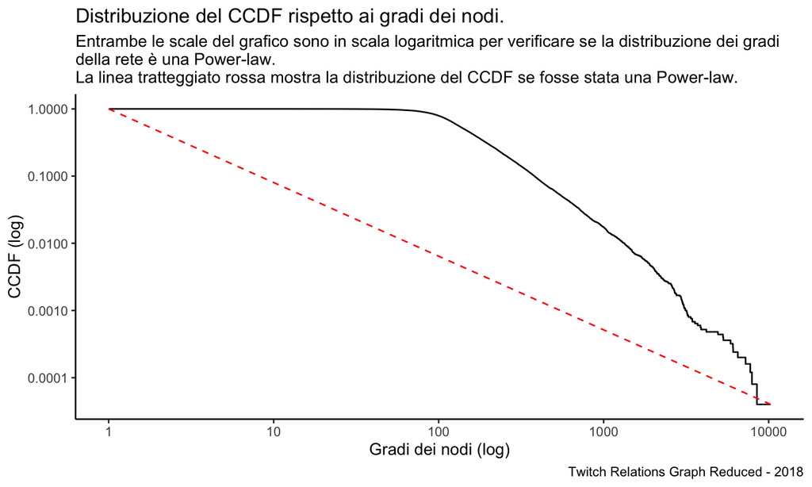

- Come è possibile osservare nel grafico della distribuzione del CCDF, e dai risultati ottenuti dai medoti precedenti, è possibile concludere che la rete sociale di *Twitch*, in esame, non è di tipo **Scale-free**.